# Course Project

# Background

Using devices such as Jawbone Up, Nike FuelBand, and Fitbit it is now possible to collect a large amount of data about personal activity relatively inexpensively. These type of devices are part of the quantified self movement – a group of enthusiasts who take measurements about themselves regularly to improve their health, to find patterns in their behavior, or because they are tech geeks. One thing that people regularly do is quantify how much of a particular activity they do, but they rarely quantify how well they do it. In this project, your goal will be to use data from accelerometers on the belt, forearm, arm, and dumbell of 6 participants. They were asked to perform barbell lifts correctly and incorrectly in 5 different ways. More information is available from the website here: http://groupware.les.inf.puc-rio.br/har (see the section on the Weight Lifting Exercise Dataset).

# Data

The training data for this project are available here:

https://d396qusza40orc.cloudfront.net/predmachlearn/pml-training.csv

The test data are available here:

https://d396qusza40orc.cloudfront.net/predmachlearn/pml-testing.csv

The data for this project come from this source: http://groupware.les.inf.puc-rio.br/har. If you use the document you create for this class for any purpose please cite them as they have been very generous in allowing their data to be used for this kind of assignment.

# What you should submit

The goal of your project is to predict the manner in which they did the exercise. This is the “classe” variable in the training set. You may use any of the other variables to predict with. You should create a report describing how you built your model, how you used cross validation, what you think the expected out of sample error is, and why you made the choices you did. You will also use your prediction model to predict 20 different test cases.

# Load libraries

```r
library(caret)
library(rpart)
library(rpart.plot)
library(rattle)
library(readr)
library(randomForest)
library(ggplot2)
```

# Read data

```r
pml_testing <- read_csv("Downloads/pml-testing.csv") # will be used for validation
pml_training <- read_csv("Downloads/pml-training.csv")
```

# Getting relevant data

Datasets contain 160 variables.

### Deleting irrelevant data

Some data won’t be needed like user_name or timestamp so I will delete them from both datasets.

```r
pml_testing <- pml_testing[, -c(1:7)]

pml_training <- pml_training[, -c(1:7)]
```

### Removing null columns and data with low variance

Some variables only have null values, I’ll remove them.

```r
pml_training <- pml_training[, colSums(is.na(pml_training)) == 0]
pml_testing <- pml_testing[, colSums(is.na(pml_testing)) == 0]
```

### Removing columns with near zero variance

```r
# function from caret library

if (length(nearZeroVar(pml_training)) > 0) {
  pml_training <- pml_training[, -nearZeroVar(pml_training)]
}

if (length(nearZeroVar(pml_testing)) > 0) {
  pml_training <- pml_testing[, -nearZeroVar(pml_testing)]
}
# No variables removed
```

### Datset check after changes

```r
dim(pml_training)
```

```
## [1] 19622    53
```

```r
dim(pml_testing)
```

```
## [1] 20 53
```

### Data type of each variable

In order to use the data for prediction, I will need to ensure that the variables are numeric and transform character variable to a factor.

```r
sapply(pml_training, class)
```

```
##            roll_belt           pitch_belt             yaw_belt
##            "numeric"            "numeric"            "numeric"
##     total_accel_belt         gyros_belt_x         gyros_belt_y
##            "numeric"            "numeric"            "numeric"
##         gyros_belt_z         accel_belt_x         accel_belt_y
##            "numeric"            "numeric"            "numeric"
##         accel_belt_z        magnet_belt_x        magnet_belt_y
##            "numeric"            "numeric"            "numeric"
##        magnet_belt_z             roll_arm            pitch_arm
##            "numeric"            "numeric"            "numeric"
##              yaw_arm      total_accel_arm          gyros_arm_x
##            "numeric"            "numeric"            "numeric"
##          gyros_arm_y          gyros_arm_z          accel_arm_x
##            "numeric"            "numeric"            "numeric"
##          accel_arm_y          accel_arm_z         magnet_arm_x
##            "numeric"            "numeric"            "numeric"
##         magnet_arm_y         magnet_arm_z        roll_dumbbell
##            "numeric"            "numeric"            "numeric"
##       pitch_dumbbell         yaw_dumbbell total_accel_dumbbell
##            "numeric"            "numeric"            "numeric"
##     gyros_dumbbell_x     gyros_dumbbell_y     gyros_dumbbell_z
##            "numeric"            "numeric"            "numeric"
##     accel_dumbbell_x     accel_dumbbell_y     accel_dumbbell_z
##            "numeric"            "numeric"            "numeric"
##    magnet_dumbbell_x    magnet_dumbbell_y    magnet_dumbbell_z
##            "numeric"            "numeric"            "numeric"
##         roll_forearm        pitch_forearm          yaw_forearm
##            "numeric"            "numeric"            "numeric"
##  total_accel_forearm      gyros_forearm_x      gyros_forearm_y
##            "numeric"            "numeric"            "numeric"
##      gyros_forearm_z      accel_forearm_x      accel_forearm_y
##            "numeric"            "numeric"            "numeric"
##      accel_forearm_z     magnet_forearm_x     magnet_forearm_y
##            "numeric"            "numeric"            "numeric"
##     magnet_forearm_z               classe
##            "numeric"          "character"
```

```r
class(pml_training$classe)
```

```
## [1] "character"
```

```r
pml_training$classe <- as.factor(pml_training$classe)
```

# Data Validation

I’ll be using my testing data as a validation sample where I’ll predict the classes. Training set will be split into training and testing data and use cross validation withing the training dataset to improve the model.

```r
set.seed(200) # to ensure reproducibility

training_sample <- createDataPartition(y=pml_training$classe, p=0.75, list=FALSE)
training_data <- pml_training[training_sample, ]
testing_data <- pml_training[-training_sample, ]
```

```r
dim(training_data)
```

```
## [1] 14718    53
```

```r
dim(testing_data)
```

```
## [1] 4904   53
```

# Data Exploration

I am going to predict a variable classe.

There are 5 different types:

- exactly according to the specification (Class A)
- throwing the elbows to the front (Class B)
- lifting the dumbbell only halfway (Class C)
- lowering the dumbbell only halfway (Class D)
- throwing the hips to the front (Class E)

```
## geom_path: Each group consists of only one observation. Do you need to adjust
## the group aesthetic?
```

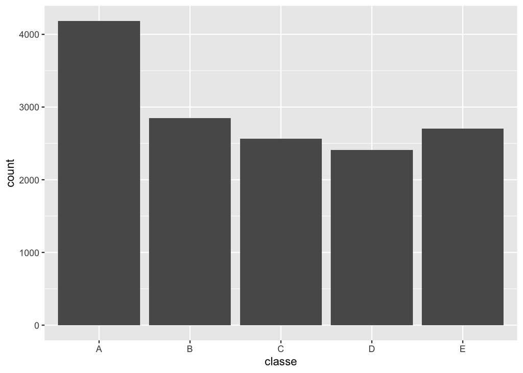

```r
ggplot(subset(training_data), aes(x=classe)) +
    geom_bar() +
    geom_line(stat="count")
```

Level A classe is the most frequent with over 4000 cases compared to least frequent D with over 2000 cases.

# Prediction Model

I am going to use:

- Decision Tree - rpart
- Random Forest - rf
- Gradient boosting trees - gbm

### Random forest

#### Create a model

```r
random_forest <- randomForest(
  classe ~ .,
  data=training_data,
  method="class"
)

random_forest
```

```
##
## Call:
##  randomForest(formula = classe ~ ., data = training_data, method = "class")
##                Type of random forest: classification
##                      Number of trees: 500
## No. of variables tried at each split: 7
##
##         OOB estimate of  error rate: 0.46%
## Confusion matrix:
##      A    B    C    D    E  class.error
## A 4181    3    1    0    0 0.0009557945
## B   12 2833    3    0    0 0.0052668539
## C    0   12 2553    2    0 0.0054538372
## D    0    0   24 2385    3 0.0111940299
## E    0    0    0    8 2698 0.0029563932
```

#### Predict

```r
rf_prediction <- predict(random_forest, testing_data, type = "class")
```

Now I am going to test results on my testing dataset (not validation dataset!)

#### Test

```r
cm_rf <- confusionMatrix(rf_prediction, testing_data$classe)
cm_rf
```

```
## Confusion Matrix and Statistics
##
##           Reference
## Prediction    A    B    C    D    E
##          A 1394    6    0    0    0
##          B    0  943    3    0    0
##          C    1    0  852    4    0
##          D    0    0    0  798    0
##          E    0    0    0    2  901
##
## Overall Statistics
##
##                Accuracy : 0.9967
##                  95% CI : (0.9947, 0.9981)
##     No Information Rate : 0.2845
##     P-Value [Acc > NIR] : < 2.2e-16
##
##                   Kappa : 0.9959
##
##  Mcnemar's Test P-Value : NA
##
## Statistics by Class:
##
##                      Class: A Class: B Class: C Class: D Class: E
## Sensitivity            0.9993   0.9937   0.9965   0.9925   1.0000
## Specificity            0.9983   0.9992   0.9988   1.0000   0.9995
## Pos Pred Value         0.9957   0.9968   0.9942   1.0000   0.9978
## Neg Pred Value         0.9997   0.9985   0.9993   0.9985   1.0000
## Prevalence             0.2845   0.1935   0.1743   0.1639   0.1837
## Detection Rate         0.2843   0.1923   0.1737   0.1627   0.1837
## Detection Prevalence   0.2855   0.1929   0.1748   0.1627   0.1841
## Balanced Accuracy      0.9988   0.9965   0.9976   0.9963   0.9998
```

Article I found useful: https://towardsdatascience.com/random-forest-in-r-f66adf80ec9

### Decision tree

#### Create a model

```r
decision_tree <- rpart(classe ~ ., data=training_data, method="class")
```

#### Predict

```r
dt_predict <- predict(decision_tree, testing_data, type = "class")
```

#### Plot decision tree

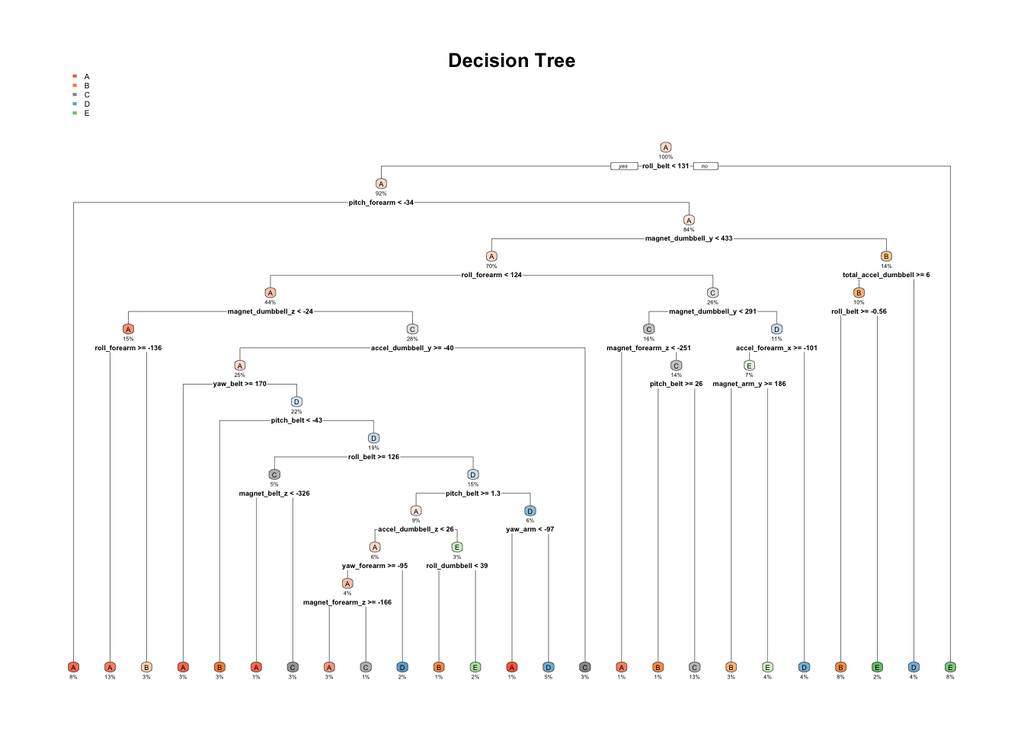

```r
rpart.plot(decision_tree, main="Decision Tree", extra=100, under=TRUE, faclen=0)
```

#### Test

```r
cm_dt <- confusionMatrix(dt_predict, testing_data$classe)
cm_dt
```

```
## Confusion Matrix and Statistics
##
##           Reference
## Prediction    A    B    C    D    E
##          A 1264  146   20   30   13
##          B   57  585   80   79   81
##          C   43   95  670  116  100
##          D   15   73   65  523   50
##          E   16   50   20   56  657
##
## Overall Statistics
##
##                Accuracy : 0.7543
##                  95% CI : (0.742, 0.7663)
##     No Information Rate : 0.2845
##     P-Value [Acc > NIR] : < 2.2e-16
##
##                   Kappa : 0.6886
##
##  Mcnemar's Test P-Value : < 2.2e-16
##
## Statistics by Class:
##
##                      Class: A Class: B Class: C Class: D Class: E
## Sensitivity            0.9061   0.6164   0.7836   0.6505   0.7292
## Specificity            0.9404   0.9249   0.9126   0.9505   0.9645
## Pos Pred Value         0.8581   0.6633   0.6543   0.7204   0.8223
## Neg Pred Value         0.9618   0.9095   0.9523   0.9327   0.9406
## Prevalence             0.2845   0.1935   0.1743   0.1639   0.1837
## Detection Rate         0.2577   0.1193   0.1366   0.1066   0.1340
## Detection Prevalence   0.3004   0.1799   0.2088   0.1480   0.1629
## Balanced Accuracy      0.9233   0.7707   0.8481   0.8005   0.8469
```

Accuracy for Decision Tree alghorithm is 75.43% with 95% CI (0.742 to 0.7663). The expected out-of-sample error is estimated at 0.2457, or 24.57%.

### Generalized Boosting Model (GBM)

#### Created a model

```r
fit_control <- trainControl(method = "repeatedcv",
                                     number = 5, repeats = 4, allowParallel = TRUE)
gbm <- train(classe ~ ., data = training_data,
                          method = "gbm", trControl = fit_control, verbose = FALSE)

# I could write the code for RF or DT in a similar way as here for GBM using caret package
```

#### Predict

```r
gbm_predict <- predict(gbm, testing_data)
```

#### Test

```r
cm_gbm <- confusionMatrix(gbm_predict, testing_data$classe)
cm_gbm
```

```
## Confusion Matrix and Statistics
##
##           Reference
## Prediction    A    B    C    D    E
##          A 1370   25    0    0    1
##          B   10  900   28    6   10
##          C   10   24  814   19    3
##          D    4    0   11  768   15
##          E    1    0    2   11  872
##
## Overall Statistics
##
##                Accuracy : 0.9633
##                  95% CI : (0.9576, 0.9684)
##     No Information Rate : 0.2845
##     P-Value [Acc > NIR] : < 2.2e-16
##
##                   Kappa : 0.9536
##
##  Mcnemar's Test P-Value : 1.925e-05
##
## Statistics by Class:
##
##                      Class: A Class: B Class: C Class: D Class: E
## Sensitivity            0.9821   0.9484   0.9520   0.9552   0.9678
## Specificity            0.9926   0.9863   0.9862   0.9927   0.9965
## Pos Pred Value         0.9814   0.9434   0.9356   0.9624   0.9842
## Neg Pred Value         0.9929   0.9876   0.9898   0.9912   0.9928
## Prevalence             0.2845   0.1935   0.1743   0.1639   0.1837
## Detection Rate         0.2794   0.1835   0.1660   0.1566   0.1778
## Detection Prevalence   0.2847   0.1945   0.1774   0.1627   0.1807
## Balanced Accuracy      0.9873   0.9674   0.9691   0.9740   0.9822
```

#### Plotting the accuracy

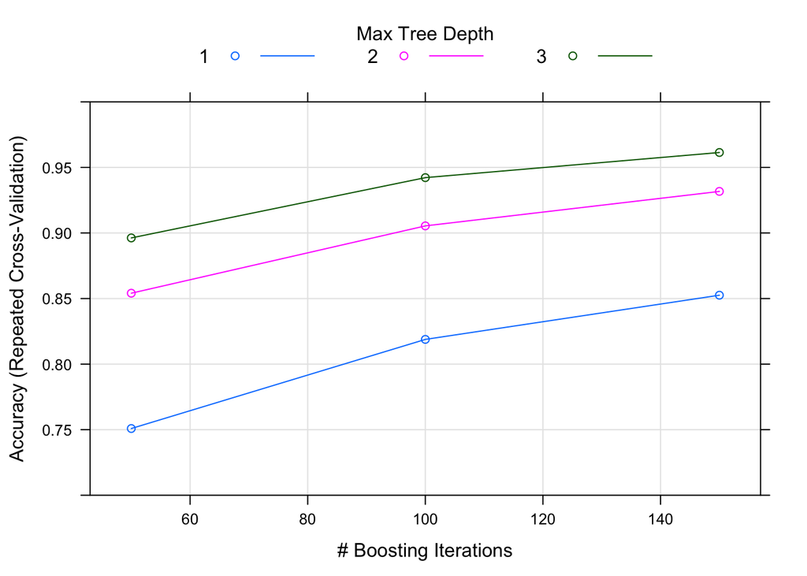

```r
plot(gbm, ylim=c(0.7, 1))
```

# Result

```r
cat("The Random Forest Accuracy = ", round(cm_rf$overall['Accuracy']*100, 2), "%", sep="")
```

```
## The Random Forest Accuracy = 99.67%
```

```r
cat("The Decision Tree = ", round(cm_dt$overall['Accuracy']*100, 2), "%", sep="")
```

```
## The Decision Tree = 75.43%
```

```r
cat("The GBM Accuracy = ", round(cm_gbm$overall['Accuracy']*100, 2), "%", sep="")
```

```
## The GBM Accuracy = 96.33%
```

The highest accuracy had random forest model.

# Prediction of classes using validation dataset

```r
predict_validation <- predict(random_forest, pml_testing)
validation_result <- data.frame(
  problem_id=pml_testing$problem_id,
  predicted=predict_validation
)

validation_result
```

```
##    problem_id predicted
## 1           1         B
## 2           2         A
## 3           3         B
## 4           4         A
## 5           5         A
## 6           6         E
## 7           7         D
## 8           8         B
## 9           9         A
## 10         10         A
## 11         11         B
## 12         12         C
## 13         13         B
## 14         14         A
## 15         15         E
## 16         16         E
## 17         17         A
## 18         18         B
## 19         19         B
## 20         20         B
```

# Outcome

In order to predict classes on validation dataset, I picked a random forest model with highest accuracy. After submitting to coursera, the result came back with 100% accuracy.